# < R : GGPLOT2을 이용한 기초 시각화 >

어느 작업을 하다보면 그림, 사진, 그래프 등 시각를 통한 자료가 필요하다. 이번 장에서는 R을 통해 그래프를 그리는 방법을 알아보도록 하자.

R에서 그래프를 그리는 방법 중 ggplot2 패키지를 이용해서 그래프를 그리는 방법을 알아보자.

그래프 커스텀(Grape Customizing)에서는 크게 타이틀(title), 축(Axis), 범례(Legend), 그래프(Grape)로 이루어져 있다.

### 1. 그래프(Grape)

ggplot2는 패키지로써 처음 사용할 때 install.packages를 이용하여 설치한뒤, library로 활성화 시켜야 사용할 수 있다. ggplot2의 실행함수는 ggplot으로 실행형태가 조금 다르다.

```r
library(ggplot2)
#gglplot(data = , mapping = aes(x= , y= )) + geom_
```

ggplot2의 기본꼴은 주석안에 있는 표현이다. ggplot의 구조는 크게 2가지로, ggplot() + geom_의 구조로 되어있다.

ggplot()은 배경을 그린다고 생각하면 되고, geom_은 그래프를 그리기 위한 설정을 하는 것이라고 생각하면 된다.

ggplot의 data는 사용할 데이터를 적으면되고, x와y는 써도 되고 안써도 된다. x,y를 쓰게 될 경우, 앞으로 그릴 그래프에서 x,y에 적은 데이터만을 x,y에 적용하여 사용하게 됨으로 여러개의 그래프를 겹쳐 그리거나, x,y가 그래프마다 달라질경우 x,y를 생략한다.

mapping은 말그대로 그래프를 그린다는 것이다. mapping을 ggplot()이나 geom_() 둘중 한 곳은 적어야 그래프가 그려진다.

geom_의 경우 _ 뒤에 오는 것에 따라 그래프의 종류가 달라진다. 종류가 많지만 그 중 자주 사용하는 것은 다음과 같다.

- geom_line : x,y 값에 따라 값들을 선으로 잇는다.(분류 기준에 따라 선을 이음)
- geom_point : x,y 값에 따라 값들을 점으로 표현
- geom_bar : x,y 값에 따라 값들을 막대그래프로 표현

x,y값의 종류에 따라 그래프로 표현이 될수도 안될 수도 있으니 주의하며 자료구조를 만들어야 한다.

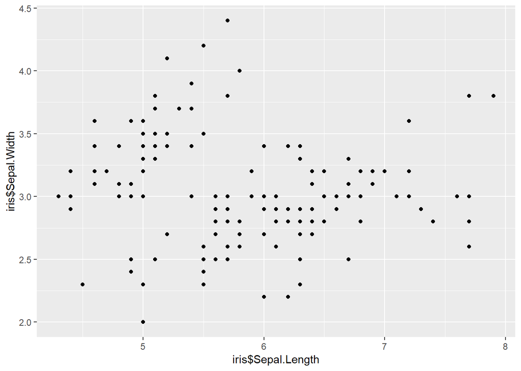

```r
library(ggplot2)
ggplot(data = iris) +
  geom_point(mapping = aes(x = iris$Sepal.Length, y = iris$Sepal.Width))
```

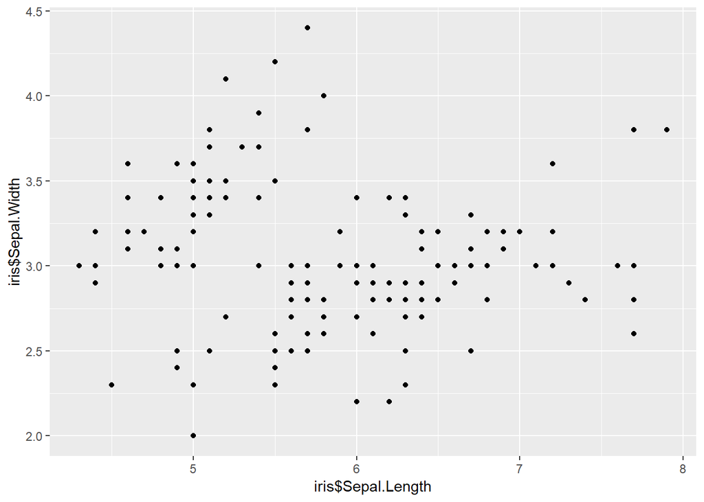

```r
ggplot(data = iris, mapping = aes(x = iris$Sepal.Length, y = iris$Sepal.Width)) +
  geom_point()
```

위에 코드를 보면 aes는 그래프를 그리기 위해 필요한 값들값을 넣어주는 함수이다.

기본적으로 들어가야될 것은 x,y축에 대한 값(1개만 쓸 수도 있다)을 지정해야한다. 2개의 코드를 실행하면 같은 그래프 2개를 호출한다.

ggplot()에다가 data를 반드시 입력해줘야 되는 것은 아니다. ggplot() + geom(data = , mapping = , …)과 같이 data를 입력을 해도 된다. 상황에 따라 코드를 작성하면 된다.

다음은 데이터 자료중에서 일부 값들만 뽑아다가 그래프를 그리는 방법이다.

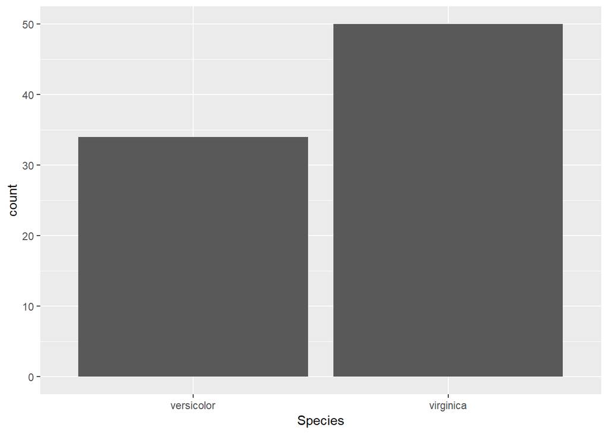

```r
ggplot(subset(iris,Petal.Length > 4)) +
  geom_bar(mapping = aes(x = Species))
```

subset을 ggplot안에 사용해서 일부 데이터만을 뽑게 조정해주면 된다.

subset(data= , 조건)과 같은 형태로 해서 사용하고, 그리프 옵션을 설정해주면된다.

다음은 어느 한 그룹으로 데이터를 분류하는 방법이다.

```r
ggplot(iris) +
  geom_point(mapping = aes(x = Petal.Length,y = Petal.Width, color = Species))
```

[output not shown]

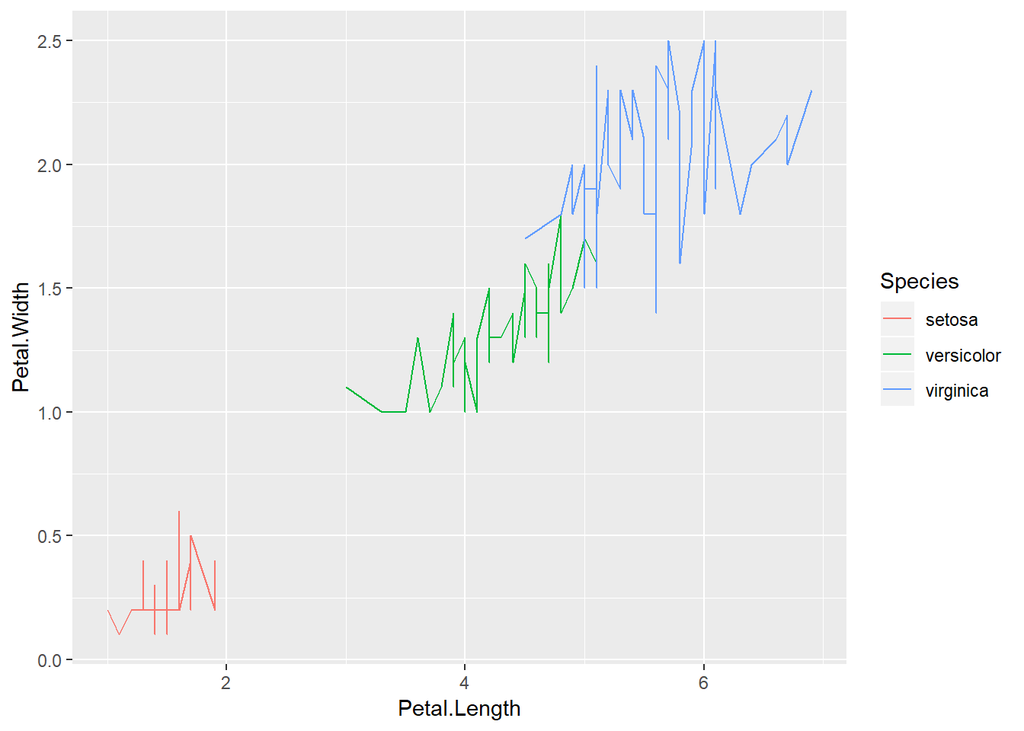

```r
ggplot(iris) +
  geom_line(mapping = aes(x = Petal.Length,y = Petal.Width, color = Species))
```

mapping 안에 color/fill이라는 옵션이 있다.

- color : 그래프 테두리의 색을 지정해주는 옵션
- fill : 그래프 내부의 색을 지정해주는 옵션

(color = colour는 같은 옵션)

color라는 옵션을 통해서 데이터들을 색으로써 분리할 수 있게끔 해준다. 여기서는 color를 Species로 지정을 했기 때문에 Species의 종류 개수에 맞춰 색깔을 자동으로 지정해준다.

보통 지정해줄 때, 데이터 내 자료로 그래프를 나눌때는 자료형태가 범주형으로 해야 정확하게 나눠진다. 값이 여러개가 나오는 데이터(ex : 연속형 변수)로 지정할 시, 단일색으로 나올 경우가 많다.

그래프를 만들때, 더 보기 좋은 그래프 방법을 만드는 것이 효과적이다.

R 내부데이터 중에 Chickweight가 있다.

Chickweight는 4개의 변수와 578개의 자료로 이루어진 데이터프레임 자료이다. (자세한 내용은 ?Chickweight를 실행해서 볼 것)

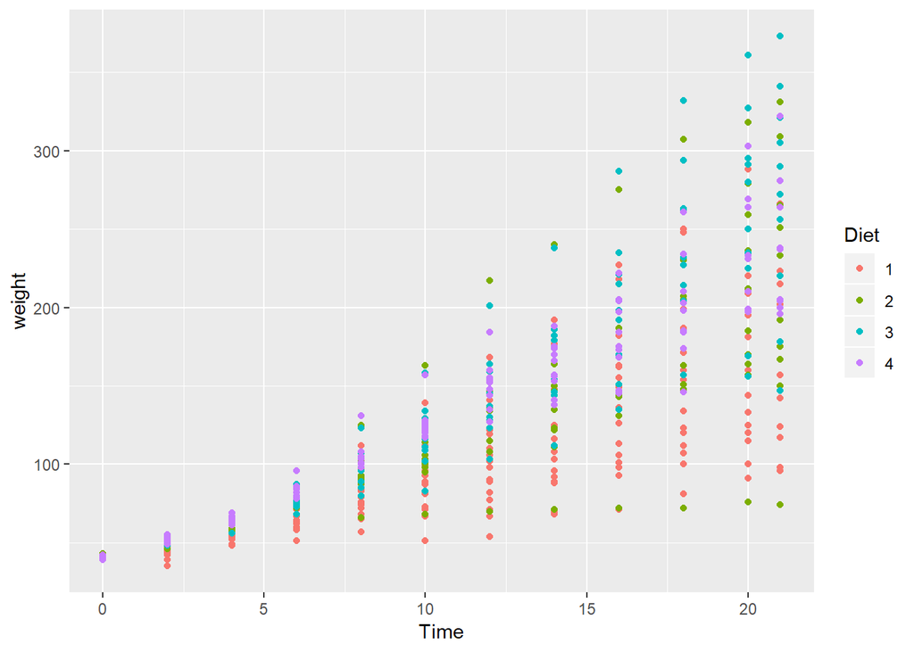

```r
ggplot(ChickWeight) +
  geom_point(mapping = aes(x = Time, y = weight, colour = Diet))
```

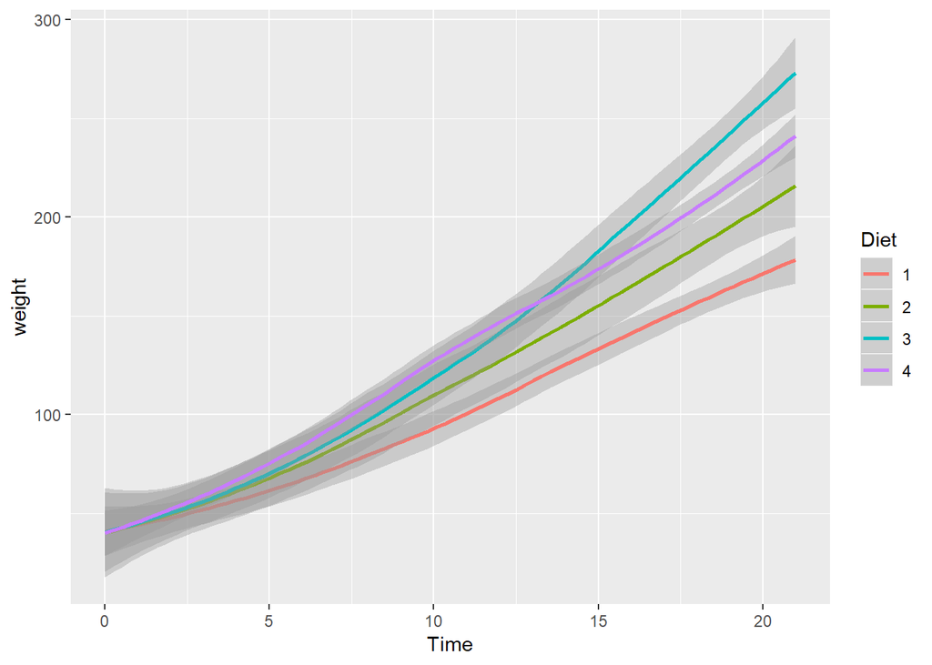

```r
ggplot(ChickWeight) +
  geom_smooth(mapping = aes(x = Time, y = weight, colour = Diet))
```

위의 geom_point/bar/line 말고도 여러가지 방법들이 더 있다.

geom_smooth 기법은 동일한 값들이 가진 값들이 존재할 수 있는 범위를 나타내주는 방법이다.

geom_xxx를 쓰다보면 mapping 말고도 다른 옵션들이 존재한다.

geom_(mapping = , data = , stat = , position = )

- stat : 데이터를 어떤식으로 통계변환 해줄것인지에 대한 옵션
- position = 그래프를 어떤식으로 그릴것인지에 대한 옵션
- color = 그래프 전체 색을 지정해주는 옵션(mapping 안의 color랑 다르니 주위!!!)

위의 옵션들은 주로 많이 쓰이는 옵션들이다.

위의 옵션들 말고도 다른 옵션들도 있으니 스스로 공부하면서 알아가도록 하자.

geom_기법마다 사용하는 용도가 다르니 사용시 유의해야한다.

R 내부 데이터 mtcars를 이용해서 그래프를 그려본다.

(mtcars data는 ?mtcars를 이용하도록 하자.)

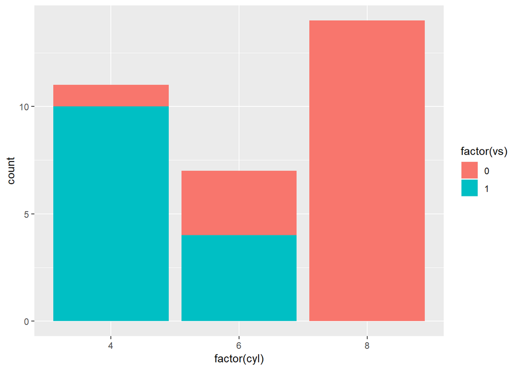

```r
ggplot(data = mtcars) +
  geom_bar(mapping = aes(factor(cyl), fill = factor(vs)))
```

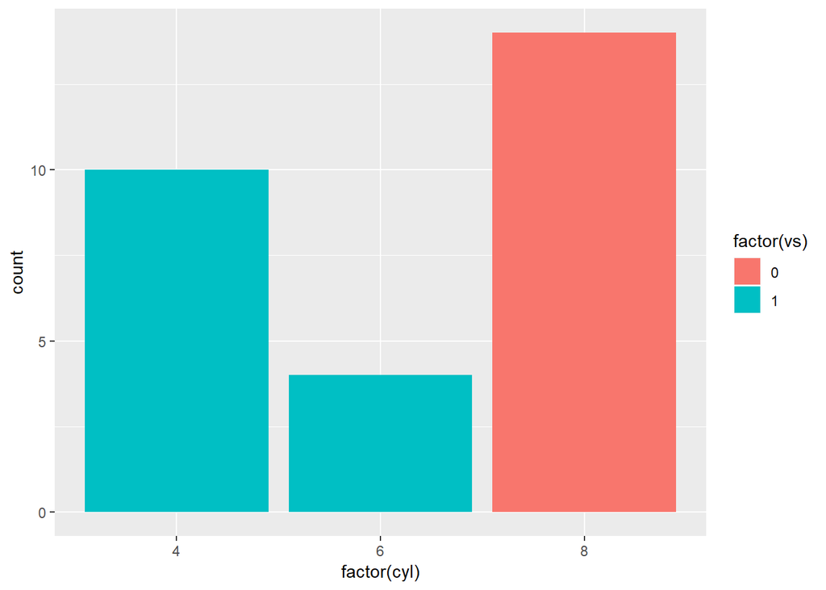

```r
ggplot(data = mtcars) +
  geom_bar(mapping = aes(factor(cyl), fill = factor(vs)), position = "identity")
```

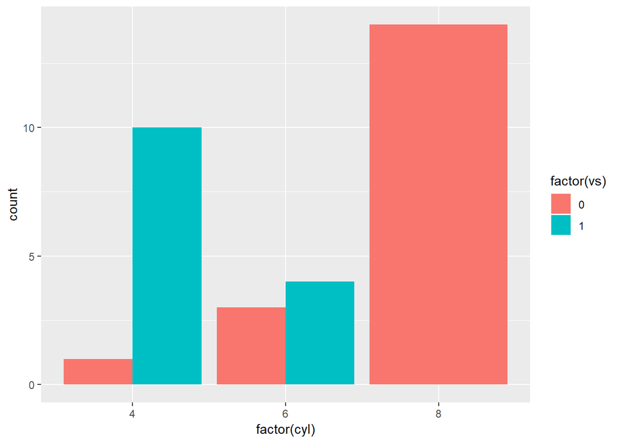

```r
ggplot(data = mtcars) +
  geom_bar(mapping = aes(factor(cyl), fill = factor(vs)), position = "dodge")
```

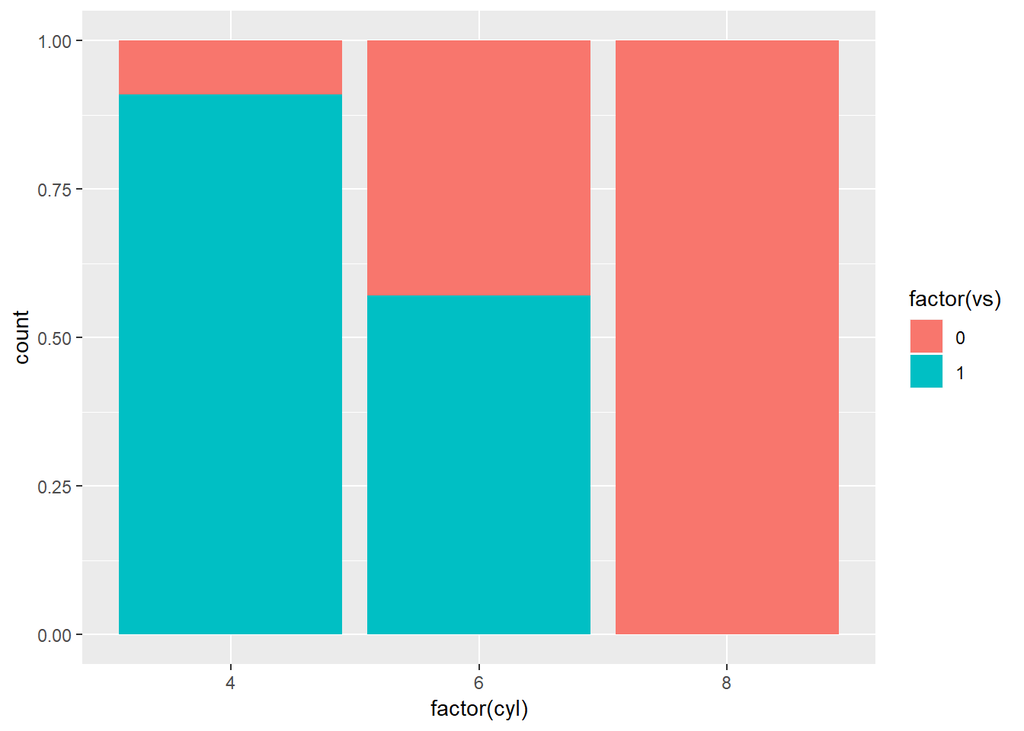

```r
ggplot(data = mtcars) +
  geom_bar(mapping = aes(factor(cyl), fill = factor(vs)), position = "fill")
```

position을 어떻게 설정해주냐에 따라서 그래프 표현방법이 달라진다.

- identity : 각 항목들에 대해서 오버랩해서 보여준다.(겹쳐서 보여준다는 것)
- dodge : 각 항목들을 분리해서 각각의 그래프로 보여준다.
- fill : 높이를 일정하게 한뒤, 각 항목별 비율을 누적해서 보여준다.

position의 경우 그리는 그래프 종류에 따라 다른 효과가 있을 수 있으므로, 해당 그래프의 표현 방식에 대해서는 따로 검색해서 찾아볼 수 있도록 하자.

……………………………………………………………………………………………………………………………………………………………………………

### 1. 연습 문제

- diamonds 데이터를 이용해서 다음의 그래프를 작성하자.(position = “jitter”로 설정할 것)

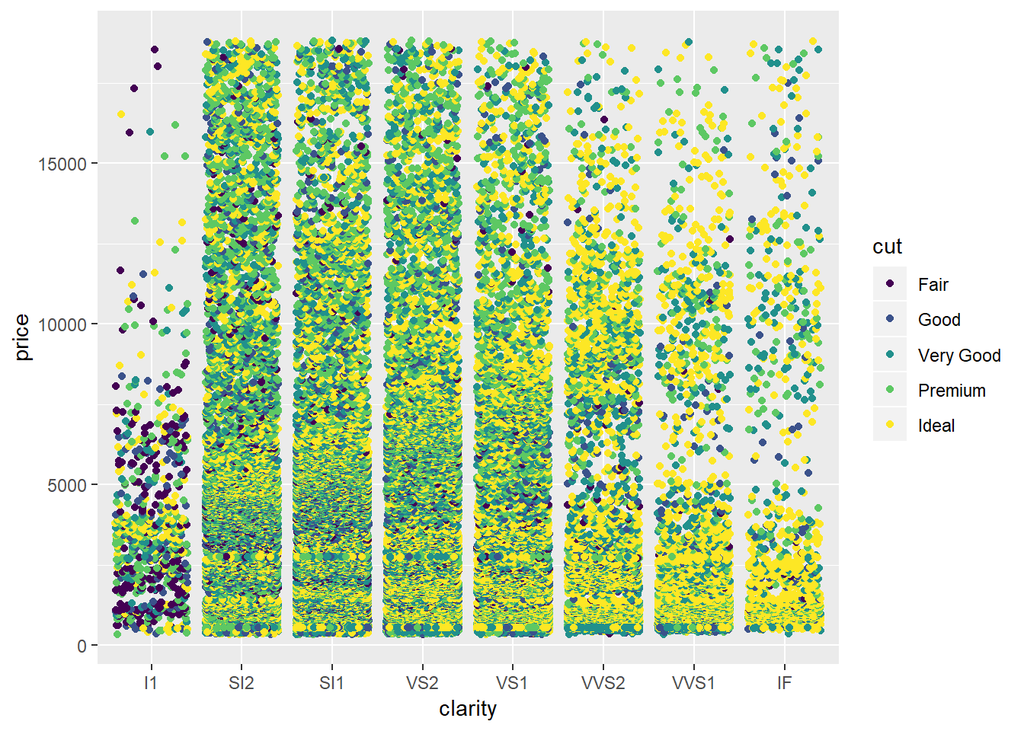

- R 내부 데이터 중에 economics(시계열데이터)가 있다. unemploy는 실업자수를, pop는 총인수이다. rate : unemploy / pop로 저정할 한 뒤, 다음 그래프를 나타내어라.

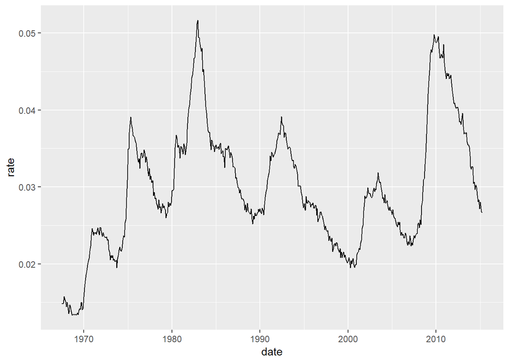

……………………………………………………………………………………………………………………………………………………………………………

### 2. 제목(Title)

위에서 그려본 그래프만 보면 제목이 없어서 어떤 것을 보고자 하는 것인지 알 수가 없다. 이번에는 그래프의 제목을 붙여보자.

위의 데이터 말고 새로운 데이터를 가지고 그래프를 그려보자.

```r
bloodtype <- c("A","B","O","AB","B","A","B","AB","A","A","A","B","O","A","B","AB","O","O","O","AB","A","B","AB","A","A","B","B","B","O","AB")
gender <- c("M","M","F","F","F","M","M","M","M","F","M","M","F","M","F","F","F","F","M","M","M","F","M","F","M","M","F","F","M","M")
height <- c(178,185,169,160,170,160,156,163,185,149,178,145,150,178,167,165,163,162,157,170,171,178,180,189,172,155,162,168,175,173)
weight <- c(79,89,56,50,74,84,57,49,87,78,60,59,48,80,71,79,105,69,50,69,82,89,93,74,81,74,67,66,54,100)

imf <- cbind(bloodtype,gender,height,weight)
rownames(imf) <- c("NO1","NO2","NO3","NO4","NO5","NO6","NO7","NO8","NO9","NO10","NO11","NO12","NO13","NO14","NO15","NO16","NO17","NO18","NO19","NO20",
                   "NO21","NO22","NO23","NO24","NO25","NO26","NO27","NO28","NO29","NO30")
imf <- as.data.frame(imf)
imf
```

```
##      bloodtype gender height weight
## NO1          A      M    178     79
## NO2          B      M    185     89
## NO3          O      F    169     56
## NO4         AB      F    160     50
## NO5          B      F    170     74
## NO6          A      M    160     84
## NO7          B      M    156     57
## NO8         AB      M    163     49
## NO9          A      M    185     87
## NO10         A      F    149     78
## NO11         A      M    178     60
## NO12         B      M    145     59
## NO13         O      F    150     48
## NO14         A      M    178     80
## NO15         B      F    167     71
## NO16        AB      F    165     79
## NO17         O      F    163    105
## NO18         O      F    162     69
## NO19         O      M    157     50
## NO20        AB      M    170     69
## NO21         A      M    171     82
## NO22         B      F    178     89
## NO23        AB      M    180     93
## NO24         A      F    189     74
## NO25         A      M    172     81
## NO26         B      M    155     74
## NO27         B      F    162     67
## NO28         B      F    168     66
## NO29         O      M    175     54
## NO30        AB      M    173    100
```

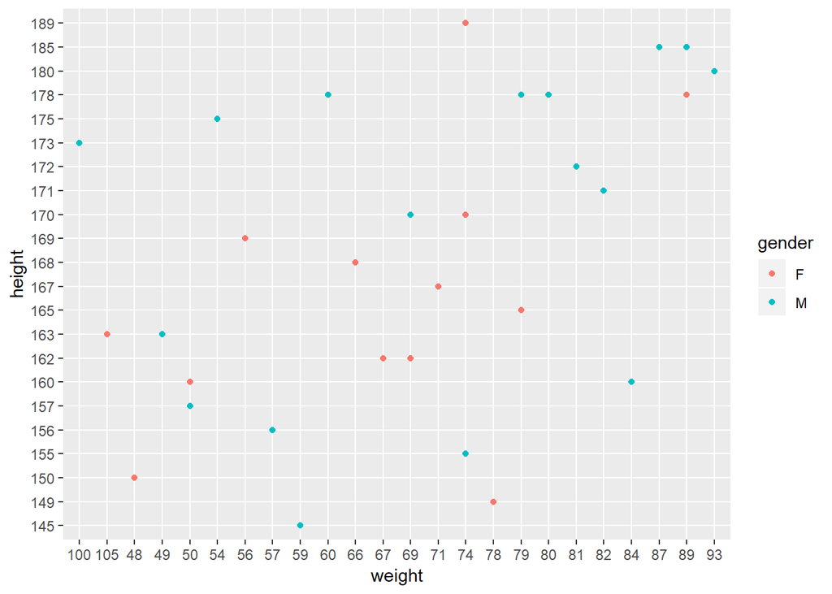

```r
gp1 <- ggplot(data = imf) +
      geom_point(aes(x = weight, y = height, color = gender))

gp2 <- ggplot(data= imf) +
      geom_bar(aes(x = gender, color = bloodtype), position = "dodge")

gp1
```

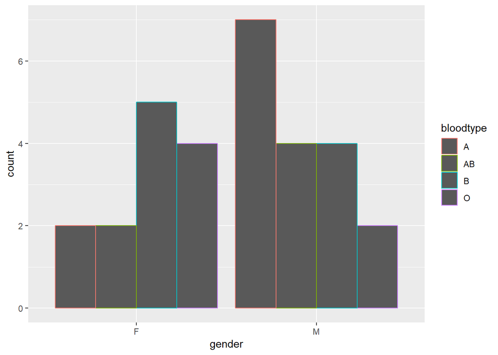

```r
gp2
```

먼저 gp1 그래프를 가지고 제목을 붙여보도록 하자.

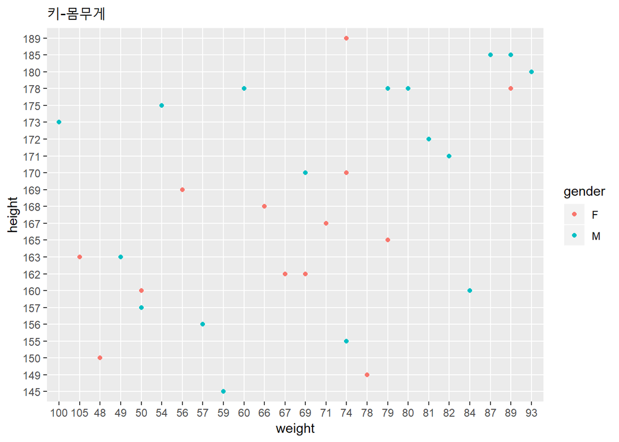

```r
gp1 +
  ggtitle(label = "키-몸무게")
```

제목을 붙이는 함수는 ggtitle을 사용한다.

ggplot() + ggtitle을 붙이는 형태로 사용한다.

위처럼 gp1에다가 코드를 저장하였기 때문에 +을 바로 붙여서 사용하면 된다.

결과를 보면 제목을 붙여졌지만 좌측 상단에다가 글씨 크기가 작아보인다.

이와 관련된 옵션을 보자.

theme함수를 통해서 옵션을 조정할 수 있다.

theme() : 글씨체, 색상, 글씨 크기 등등을 조정하게 해주는 함수

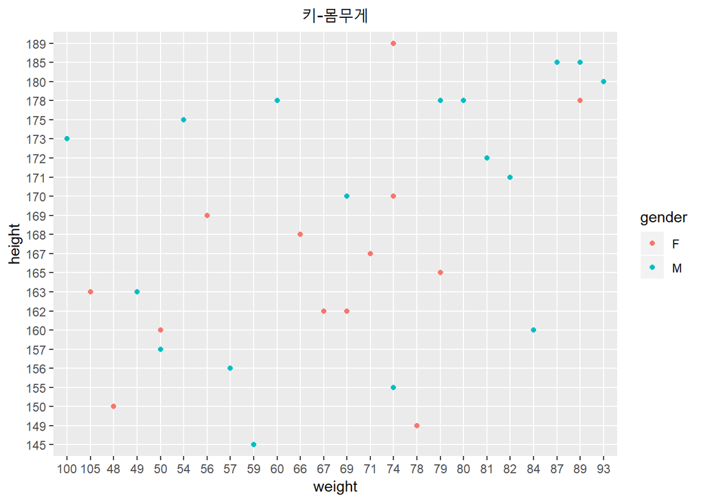

```r
gp1 +
  ggtitle(label = "키-몸무게") +
  theme(plot.title = element_text(size = 13, hjust = 0.5, color = "black"))
```

theme함수 내에서 어디를 수정할 건지 입력을 해주어야한다. 위에서는 그래프의 제목을 수정하는 것이므르 theme(plot.title = )를 입력하였다.

plot.title을 어떻게 수정할 것인지에 대한 것 중 글자에 대한 부분은 element_text로 수정한다.

element_text()의 옵션

- family : 글자 종류를 지정
- face : 글자 모양 지정 (ex : “plain”,“italic”,“bold”,“bold.italic”)
- color/colour : 글자 색상 지정
- size : 글자 크기 지정
- hjust : 글자 위치 수평 지정
- vjust : 글자 위치 수직 지정
- angle : 글자 각도 조정(0 ~ 360)
- margin : 글자 주변 공간 지정
- lineheight : 글자 선 위치 지정

글꼴, 글자 색깔, 글자 모양은 ""을 써야 인식을 한다.

글꼴, 글자 색깔, 글자 모양은 구글링을 통해 원하는 것을 선택해 적용하도록 한다.

gp2에다 element_text를 적용하여 그려보면,

```r
library(extrafont)
library(showtext)
```

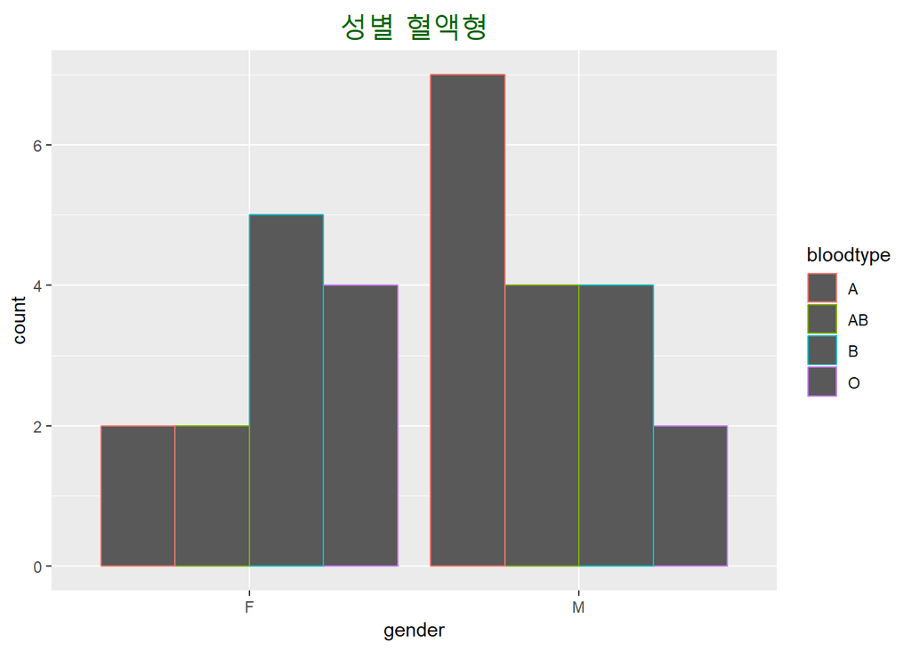

```r
gp2 +
  ggtitle(label = "성별 혈액형") +
  theme(plot.title = element_text(family = "Nanum Pen Script",
                                  face = "plain",
                                  color = "dark green",
                                  size = 20,
                                  hjust = 0.5))
```

package인 extrafont, showtext는 폰트를 사용하게 해주는 패키지이다.

둘의 차이점은 extrafont는 pc내부에 저장된 글꼴을 사용하게 해주는 것이고, showtext는 인터넷 상에서 올라온 글꼴을 내려받아 사용하게 해주는 것이다. 인터넷 상의 글꼴은 직접 검색하여 찾아보도록 하자. 윈도우에 저장된 기본 글꼴의 종류는 구글링을 통해서 영문 표기법을 알아내던가 아니면 프로그램 “한글”/“워드”에 들어가서 글꼴을 영문으로 바꿔서 나오는 목록을 참고하여 입력하도록 하자.

그럼 제목을 정하고 부제를 적는 방법은 다음과 같다.

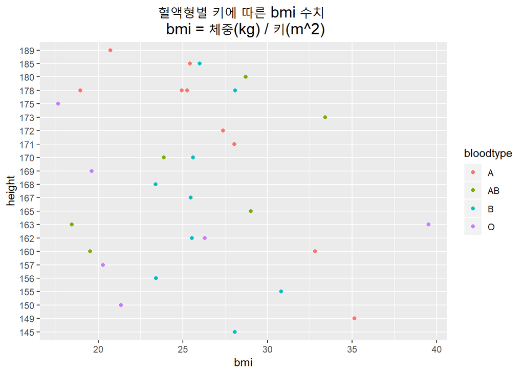

```r
bmi <- weight / ((height/100)*(height/100))
imf <- cbind(imf,bmi)

gp3 <-  ggplot(data = imf) +
            geom_point(mapping = aes(x = bmi , y = height, color = bloodtype))

gp3 +
  ggtitle("혈액형별 키에 따른 bmi 수치 \n bmi = 체중(kg) / 키(m^2)") +
  theme(plot.title = element_text(hjust = 0.5, size = 15))
```

\n을 통해서 줄바꿈을 해서 표현하면 된다.

x,y축을 바꾸고 싶으면 coord_flip() 옵션을 추가해주면 된다.

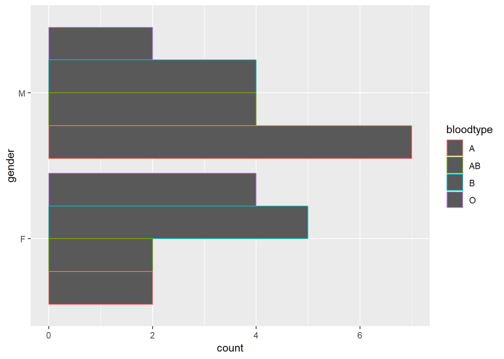

```r
gp2 + coord_flip()
```

……………………………………………………………………………………………………………………………………………………………………………

### 2. 연습문제

연습문제 1에서 풀었던 그래프에 각각 알맞은 제목을 넣어라.

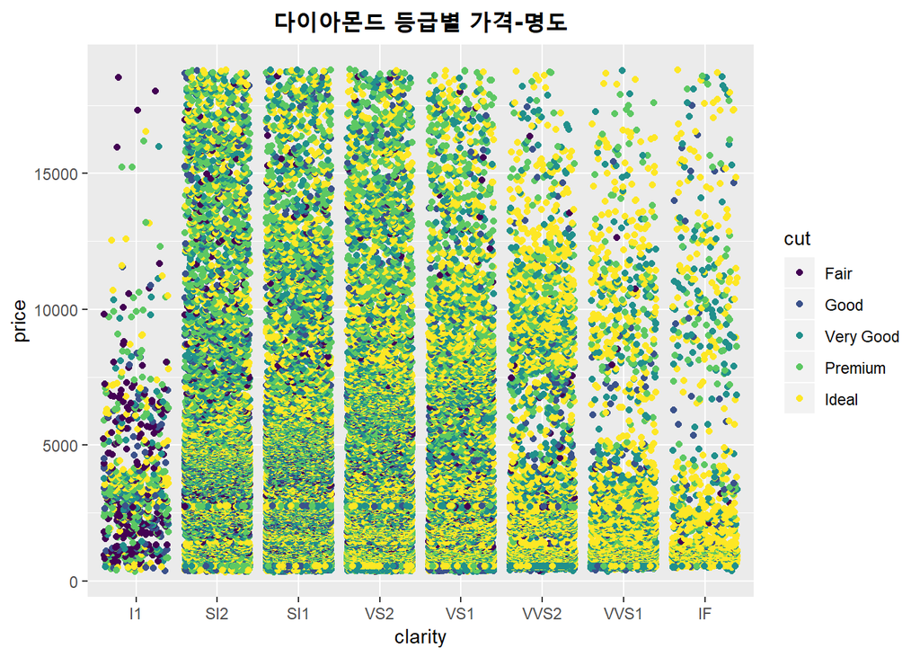

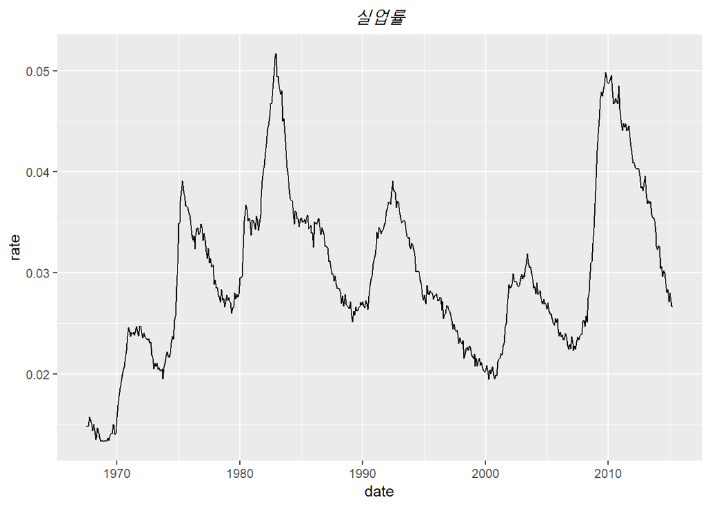

……………………………………………………………………………………………………………………………………………………………………………

### 3. 축(Axis)

그래프 상에서 축을 수정하게 되는 상황은 대게 축의 범위 수정, 축의 제목 수정, 축의 라벨 표현 수정 등 여러가지가 있다. 이에 대해 알아보도록 하자.

#### 축 제목 수정하기

위에서 타이틀 제목을 수정하는 방법과 동일하다.

다만, 차이점이 있다면 plot.title 대신 axis.title로 바꾸고 동일하게 코드를 짜면 된다.

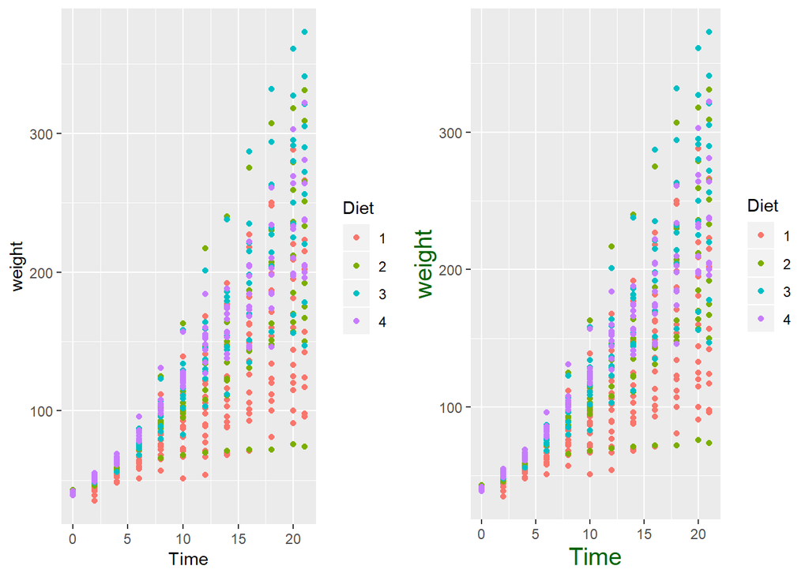

```r
library(gridExtra)

gp4 <- ggplot(ChickWeight) +
        geom_point(mapping = aes(x = Time, y = weight, color = Diet))

gp4_1 <-ggplot(ChickWeight) +
          geom_point(mapping = aes(x = Time, y = weight, color = Diet)) +
          theme(axis.title = element_text(
                                  face = "plain",
                                  size = 15,
                                  color = "dark green"))

grid.arrange(gp4,gp4_1, ncol = 2)
```

1,2번째 그래프를 비교해서 차이점을 비교하도록 하자.

gird.arrange는 그래프를 동시에 그리게 해주는 함수이다.(packages = gridExtra)

그렇다면 축의 제목을 바꾸는 것은 어떻게 할까? 위에서 보시다시피 축제목은 x,y와 넣어주는 값 그대로 따라간다. 따라서 축제목을 달리 해주기 위해서는 다른 코드를 입력해야한다.

제목은 ggtitle로 입력을 했다면, 축의 제목은 labs를 이용한다.

labs(x = "“, y =”")의 형태로 코드를 작성하면 된다.

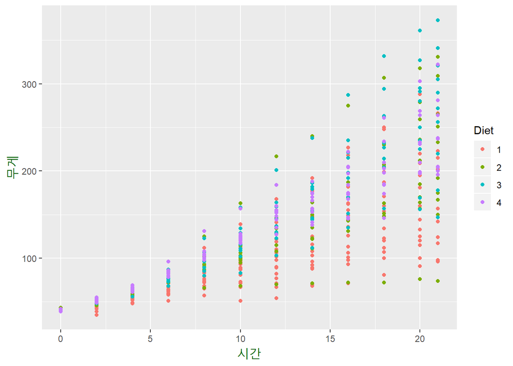

```r
gp4_1 +
  labs(x = "시간", y= "무게")
```

영어로 된 축의 이름들이 한글로 바뀐 것을 확인할 수 있다.

가끔 단위를 써주기 위해서 제목과 더불어 쓸때 보통 제목 글자 크기보다는 작게 쓴다. 이럴 때는 다음과 같이 해주면된다.

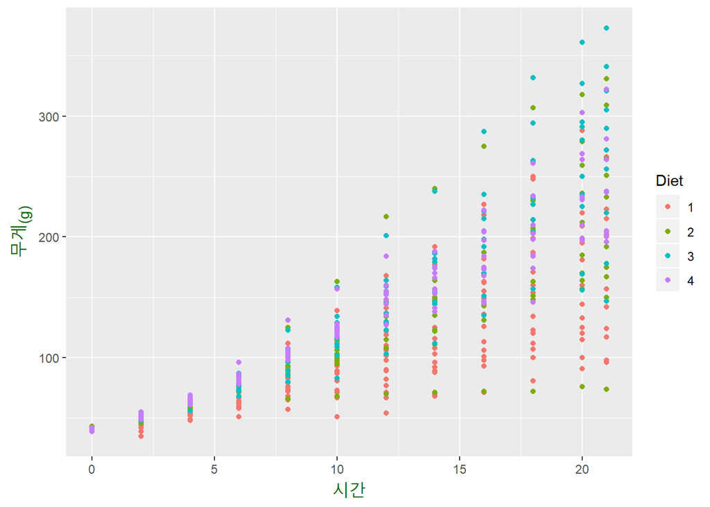

```r
gp4_1 +
  labs(x = "시간", y = expression("무게"['(g)']))
```

#### 축 범위 수정하기

다음 그래프를 보자

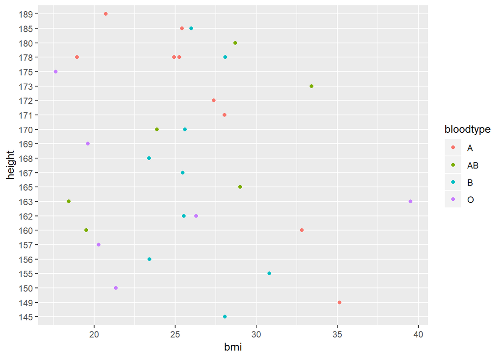

```r
gp3
```

bmi의 범위가 15 이상 40이하로 제한되어있다.

범위를 20 ~ 30 사이의 값만 보도록 해보자.

이때 쓰는 함수는 lims이다.

lims(x=c(Min,Max), y = c(Min,Max)) 형태로 쓰면 되는데 x,y축 중 둘 중 하나만 바꿀 때는 한쪽만 입력하면 된다.

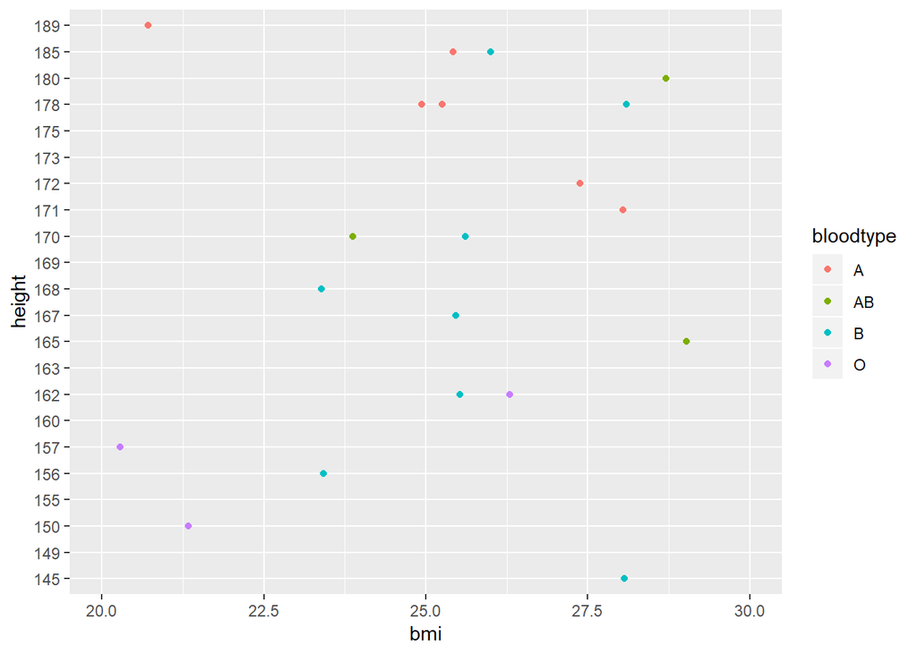

```r
gp3 +
  lims(x = c(20,30))
```

그래프를 그리다보면 축 라벨(축의 범위)가 원하는 바와 다르게 나오는 경우도 있다.

gp3 그래프의 x축 범위는 대략 15 ~ 40까지 표현을 해놓았다.

만약의 제일 좌측값의 값을 정확히 보기 위해 x축의 최소값을 더 낮추는 경우를 원하는 경우 다음과 같이 하면 된다.

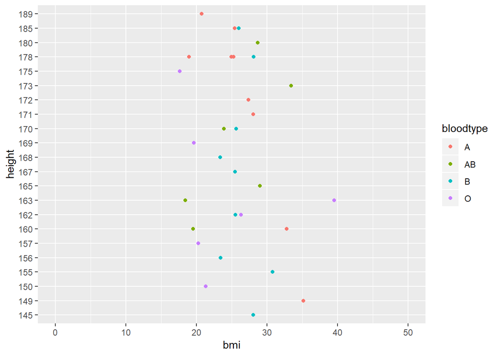

```r
gp3 +
  lims(x = c(0,50))
```

lims을 이용해 원하는 범위를 볼 수 있도록 하면 된다.

#### 축 단위 바꾸기

위의 그래프들 중 iris 데이터를 이용한 그래프를 보자.

```r
ggplot(data = iris) +
  geom_point(mapping = aes(x = Petal.Length, y = Petal.Width, color = Species))
```

[output not shown]

이 그래프의 단위를 1씩 증가하도록 하는 방법은 다음과 같다.

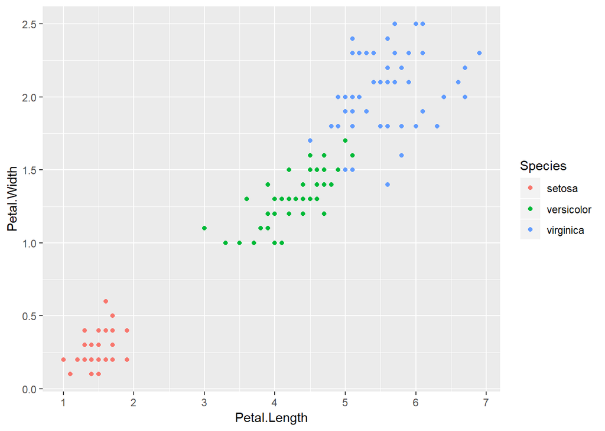

```r
ggplot(data = iris) +
  geom_point(mapping = aes(x = Petal.Length, y = Petal.Width, color = Species)) +
  scale_x_continuous(breaks = c(1,2,3,4,5,6,7))
```

scale_x/y_continuous의 옵션은 다음과 같다.(더 많은 옵션은 ?을 통해서 찾아볼 것)

- name : 축의 이름을 설정한다.
- breaks : 축의 범위를 설정한다.(숫자벡터여야함)
- labels : 축의 범위를 설정한다.(문자로 된 것일 때 사용/문자 +숫자로 된 것일 때 사용)
- position : 축의 위치를 설정한다. (left, right, top, bottom)
- sec.axis : 2번째 축을 명시한다.
- na.value : NA값을 설정한 값으로 대체한다.

위의 옵션들을 더 사용해서 시각화해보면,

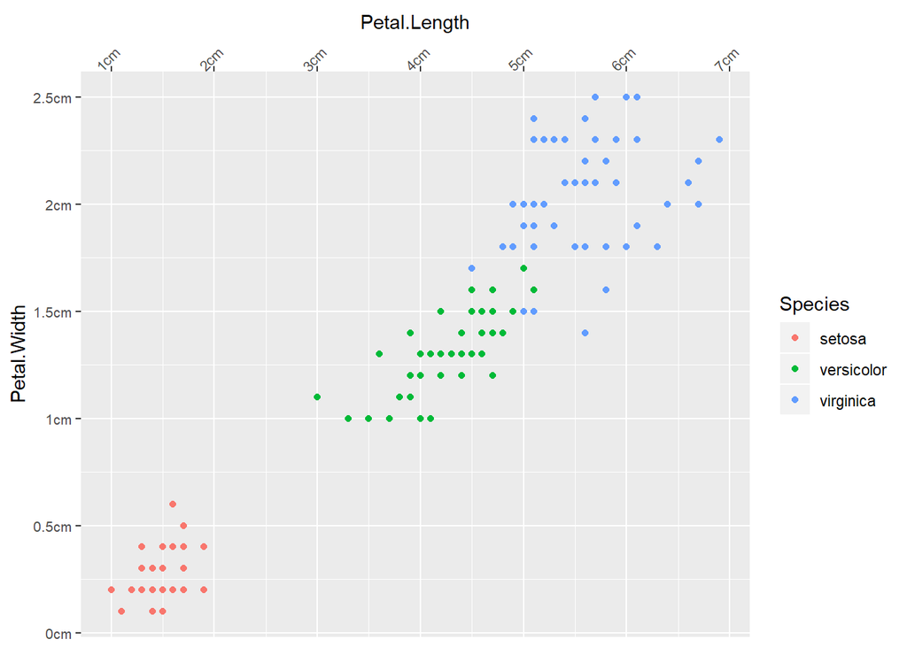

```r
ggplot(data = iris) +
  geom_point(mapping = aes(x = Petal.Length, y = Petal.Width, color = Species)) +
  scale_x_continuous(breaks = c(1,2,3,4,5,6,7), labels = paste0(c(1,2,3,4,5,6,7),"cm"), position = "top") +
  theme(axis.text.x = element_text(angle = 45, size = 8)) +
  scale_y_continuous(breaks = c(0,0.5,1,1.5,2,2.5),labels = paste0(c(0,0.5,1,1.5,2,2.5), "cm")) +
  theme(axis.text.y = element_text(size = 8))
```

openflights.org의 데이터를 기반으로 항공데이터를 시각화 해보도록 하자.

```r
airport <- read.csv("~/동아리/R문서(개인)/R을 이용한 시각화/airports.dat",sep = ",",header = F, stringsAsFactor = F)
route <- read.csv("~/동아리/R문서(개인)/R을 이용한 시각화/routes.dat",sep = ",",header = F, stringsAsFactor = F)
colnames(airport) <- c("Airport ID","Name","City","Country","IATA","ICAO","Latitude","Longitude","Altitude","Timezone","DST")
colnames(route) <- c("Airline","Airline ID","Source airport","Source airport ID","Destination airport","Destination airport ID","Codershare","Stops","Equipment")
```

airport 변수들의 데이터 설명 및 데이터 다운은 https://openflights.org/data.html 에 들어가서 하도록 하자. ……………………………………………………………………………………………………………………………………………………………………………

[output not shown]

#### 연습문제 3

1. loc 데이터를 이용해서 다음과 같이 드시오.

```
## 'data.frame':    36 obs. of  5 variables:
##  $ Airport   : chr  "CJJ" "CJU" "GMP" "HIN" ...
##  $ Latitude  : chr  "3718" "3264" "3832" "3505" ...
##  $ Longtitude: chr  "4426" "4408" "4413" "4435" ...
##  $ grp       : chr  "1" "2" "3" "4" ...
##  $ dec       : chr  "depart" "depart" "depart" "depart" ...
```

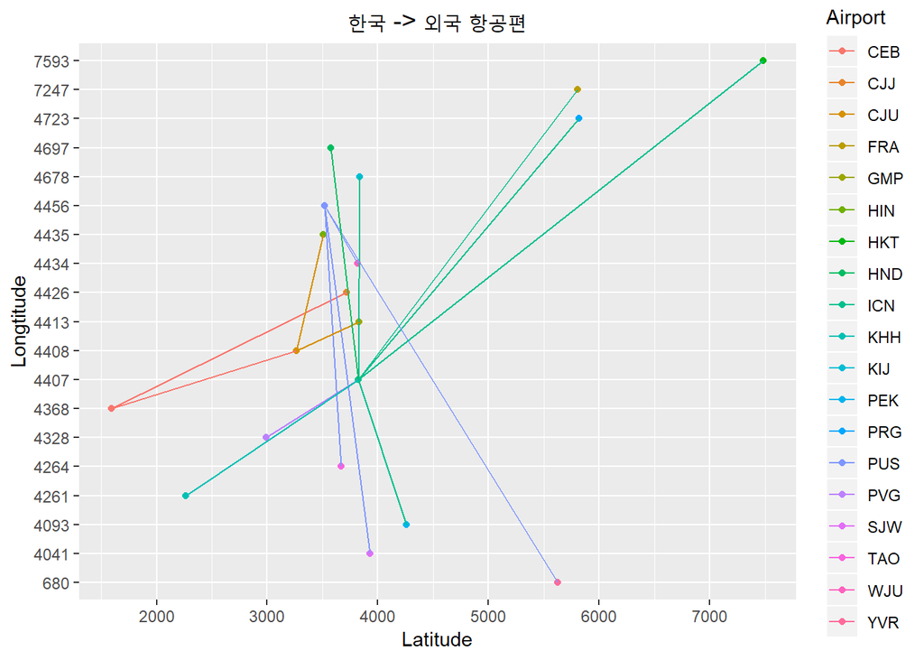

……………………………………………………………………………………………………………………………………………………………………………

### 4. 범례(Legend)

연습문제 3을 보면, 어느정도 알아 볼 수 있게 그래프가 그려졌다. 하지만, 범례를 보면 많은 항목이 입력은 되어있으나, 실제 그래프상 데이터를 보면 그렇게 많지가 않다. 따라서 불필요한 정보를 담고 있는 범례를 다루는 방법을 알아보자.

일단 범례를 다루는 함수는 theme이다.

```
theme함수

- legend.position : 범례의 위치를 설정(none = 범례제거)

- legend.title : 범례의 제목을 설정

- legend.text : 범례의 항목 글자를 설정

- legend.key : 범례의 아이콘의 테두리을 설정

- legend.box.background : 범례의 테두리를 설정
```

먼저 범례의 옵션을 추가하여 바꿔보자.

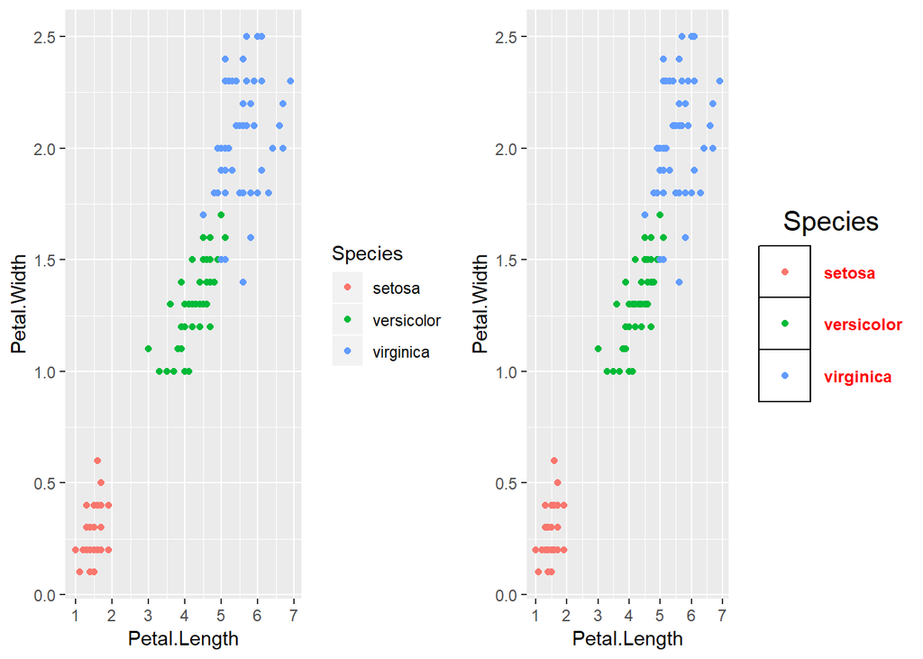

```r
iris_1 <- ggplot(data = iris) +
            geom_point(mapping = aes(x = Petal.Length, y = Petal.Width, color = Species)) +
            scale_x_continuous(breaks = c(1,2,3,4,5,6,7))

iris_2<- iris_1 + theme(legend.title = element_text(size = 15, hjust = 0.5),
               legend.text = element_text(face = "bold", size = 9, color ="red"),
               legend.key = element_rect(color = "black", fill = "white"),
               legend.key.size = unit(1,"cm"))

grid.arrange(iris_1,iris_2,ncol = 2)
```

legend.key.size는 테두리의 넓이를 지정하는 옵션이다. unit를 이용하여 변의 길이를 입력하고 단위를 입력하면 그에 따른 아이콘이 생성이 된다.

범례의 전체 테두리를 꾸며주는 방법은 다음과 같다.

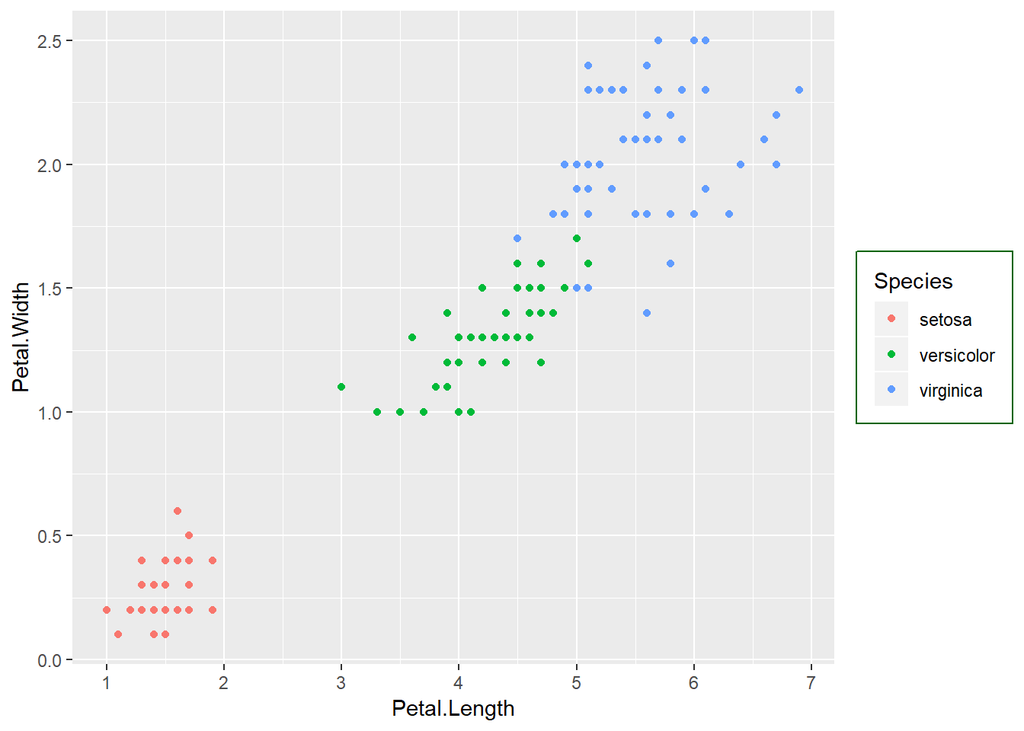

```r
iris_1 +
  theme(legend.box.background =  element_rect(color = "darkgreen", fill = "white"), legend.box.margin = margin(t = 3, r = 3, b = 3, l = 3))
```

theme(legned.box.margin = margin(t,r,b,l))는 테두리의 두께를 설정하는 옵션으로서, t = top, r = right, b = bottom, l = left를 의미하고, 각각의 두께를 입력하면 된다.

```
element_rect 옵션

- fill : 배경의 색상을 지정한다.

- color/color : 테두리의 색상을 지정한다.

- size : 테두리의 두께를 지정한다.

- linetype : 테두리 선의 종류를 지정한다.

- inherit.blank : 상위 elements의 blank 상속 여부 설정(디폴트 : F)
```